# US ZIP Maps

You can create a visualization of US ZIP codes with the function `zip_map`:

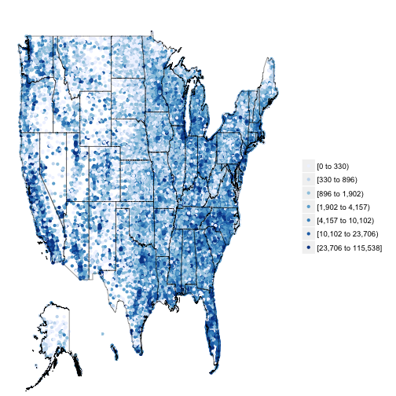

```r
library(choroplethr)

?df_pop_zip
data(df_pop_zip)

?zip_map
zip_map(df_pop_zip)
```

As demonstrated above, the only required parameter to `zip_map` is a data.frame. You can see the optional parameters by typing `?zip_map`.

Note that this visualization is a scatterplot where the position of each dot represents the longitude and latitude of the zip code and the value is expressed as a color. Also, boundaries of the states are drawn. But because boundaries of the zip codes are not drawn, this visualization is not technically a choropleth.

# Data Requirements

The data.frame that you provide to `zip_map` must have one column named “region” and one column named “value”. Your entries for “region” must **exactly** match how zip codes are named in the `zipcode` package, which is how choroplethr gets the longitude and latitude of the zip codes:

```r
library(zipcode)

?zipcode
data(zipcode)
head(zipcode)
```

```
##     zip       city state latitude longitude
## 1 00210 Portsmouth    NH  43.0059  -71.0132
## 2 00211 Portsmouth    NH  43.0059  -71.0132
## 3 00212 Portsmouth    NH  43.0059  -71.0132
## 4 00213 Portsmouth    NH  43.0059  -71.0132
## 5 00214 Portsmouth    NH  43.0059  -71.0132
## 6 00215 Portsmouth    NH  43.0059  -71.0132
```

That is, you must use a five digit character representation of the ZIP code.

# Exploring Data

The `zip_map` function provides two parameters to facilitate exploring data: `buckets` and `zoom`. buckets defaults to 7, which means that there are 7 colors, and an equal number of counties in each color. Valid values for buckets are integers betwen 1 and 7. If buckets is 1 then a continuous scale will be used. zoom defaults to NULL, which means that all counties are shown. You can set it to be a vector of states. You must name your states as defined in the “region” column of `?state.regions`.

As an example, here is how you can use choroplethr to show the population of US ZIP codes on the West Coast.

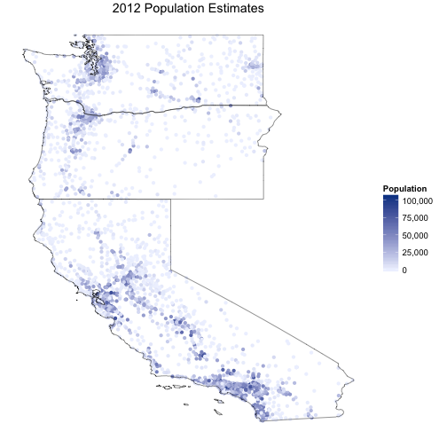

```r
zip_map(df_pop_zip,
        title   = "2012 Population Estimates",
        legend  = "Population",
        buckets = 1,
        zoom    = c("california", "washington", "oregon"))
```

# Advanced Options

Any customization outside the optional parameters presented above will require you to create a `ZipMap` object. choroplethr uses R6 to take advantage of object-oriented programming. Here is an example of using the `ggplot2_scale` on the base Choropleth object to customize the palette used.

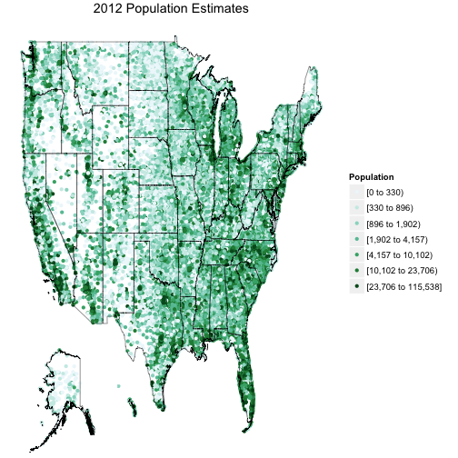

```r
library(ggplot2)

choro = ZipMap$new(df_pop_zip)
choro$title = "2012 Population Estimates"
choro$ggplot_scale = scale_color_brewer(name="Population", palette=2, drop=FALSE)
choro$render()
```

**Note:** Care must be taken when manually setting the scale on `ZipMap` objects. In particular, choroplethr uses ggplot2 custom annotations to render Alaska and Hawaii as insets. This means that the scales of the insets and the main map will only be the same if you do the following

1. for discrete scales, pass `drop=FALSE` to the scale (as above).
2. for continuous scales, pass `limits` which encompass the minimum and maximum values for the entire dataset.